# GSD and GP regression - week 4

2025-11-06

# GSD simulations

## Triangular boundaries

Correcting the equations for triangular boundaries.

First, pull the GSD simulations code that includes calculations for type I error ($\alpha$) and power.

```r
gsd_simulations <- function(n_analyses = 3,
                            upper_bounds = c(2.5, 2, 1.5),
                            lower_bounds = c(0, 0.75, 1.5),
                            n_patients = c(20, 40, 60),
                            null_hypothesis = 0,
                            alt_hypothesis = 0.5,
                            variance = 1) {

  # sanity checks
  # sanity checks, function stops
  if(length(upper_bounds) != length(lower_bounds)) {
    stop("Warning: number of upper bounds must equal number of lower bounds")
  }

  if(length(n_patients) != length(upper_bounds)) {
    stop("Warning: number of patients vector must equal number of bounds")
  }

  if(n_analyses != length(upper_bounds)) {
    stop("Warning: number of analyses must equal number of bounds")
  }

  # assign values for null and alt hypotheses
  theta_0 <- null_hypothesis
  delta <- alt_hypothesis

  # empty mean vectors to fill
  mean_0 <- c()
  mean_1 <- c()

  # need to parse the upper and lower boundaries of the design
  # for futility and efficacy, must put the bounds of integration correctly
  # for pmvnorm
  futility_l_bounds <- list()
  futility_u_bounds <- list()
  efficacy_l_bounds <- list()
  efficacy_u_bounds <- list()

  n_analyses <- length(upper_bounds)

  for (i in 1:n_analyses) {

    # special case of i = 1
    if (i == 1) {
      futility_l_bounds[[i]] <- lower_bounds[i]
      futility_u_bounds[[i]] <- upper_bounds[i]
      efficacy_l_bounds[[i]] <- lower_bounds[i]
      efficacy_u_bounds[[i]] <- upper_bounds[i]
      next
    }

    # all other cases
    futility_l_bounds[[i]] <- c(lower_bounds[1:i-1], -Inf)
    futility_u_bounds[[i]] <- c(upper_bounds[1:i-1], lower_bounds[i])

    efficacy_l_bounds[[i]] <- c(lower_bounds[1:i-1], upper_bounds[i])
    efficacy_u_bounds[[i]] <- c(upper_bounds[1:i-1], Inf)
  }

  # list of probabilities to return
  probs_to_return <- list()

  # list of SIGMAs
  SIGMA_list <- list()

  for (i in 1:n_analyses) {
    if (i == 1) next

    # start with diagonal matrix for SIGMA
    SIGMA <- diag(nrow = i)

    # n = 2, need to fill all but 11, 22
    # n = 3, need to fill all but 11, 22, 33
    # n = 4, need to fill all but 11, 22, 33, 44
    # etc.
    for(i in 1:i) {
      for(j  in 1:i) {

        # leave the 1s on the diagonal, skip this iteration of for loop
        if(i == j) next

        # when i is less than j, the lower number of patients will be in numerator
        if(i < j) SIGMA[i,j] <- sqrt(n_patients[i] / n_patients[j])

        # when i is greater than j, the lower number of patients will be in numerator
        if(i > j) SIGMA[i,j] <- sqrt(n_patients[j] / n_patients[i])

      }
    }

    SIGMA_list[[i]] <- SIGMA
  }


  for (i in 1:n_analyses) {

    ##############
    # ANALYSIS 1 #
    ##############
    if(i == 1) {
      # mean under null
      mean_0[i] <- theta_0 * sqrt(n_patients[i]/(2*variance))

      # mean under alternative
      mean_1[i] <- delta * sqrt(n_patients[i]/(2*variance))

      # prob stop for futility, null
      futility_null <- pnorm(futility_l_bounds[[i]],
                             mean = mean_0,
                             sd = sqrt(variance))

      # prob stop for efficacy, null
      efficacy_null <- pnorm(efficacy_u_bounds[[i]],
                             mean = mean_0,
                             sd = sqrt(variance),
                             lower.tail = FALSE)

      # prob stop for futility, alt
      futility_alt <- pnorm(futility_l_bounds[[i]],
                            mean = mean_1,
                            sd = sqrt(variance))

      # prob stop for efficacy
      efficacy_alt <- pnorm(efficacy_u_bounds[[i]],
                            mean = mean_1,
                            sd = sqrt(variance),
                            lower.tail = FALSE)

      probs_to_return[[i]] <- c(futility_null, efficacy_null, futility_alt, efficacy_alt)
      names(probs_to_return[[i]]) <- c("futility_null", "efficacy_null", "futility_alt", "efficacy_alt")

      next
    }

    ######################
    # ALL OTHER ANALYSES #
    ######################

    # next mean under null
    mean_0[i] <- theta_0 * sqrt(n_patients[i] / (2 * variance))

    # next mean under alternative
    mean_1[i] <- delta * sqrt(n_patients[i]/ (2*variance))

    # bounds for these will be same
    # futility under null
    futility_null <- pmvnorm(lower = futility_l_bounds[[i]],
                             upper = futility_u_bounds[[i]],
                             mean = mean_0, corr = SIGMA_list[[i]])
    # futility under alt
    futility_alt <- pmvnorm(lower = futility_l_bounds[[i]],
                            upper = futility_u_bounds[[i]],
                            mean = mean_1, corr = SIGMA_list[[i]])

    # bounds for these will be same
    # futility under null
    efficacy_null <- pmvnorm(lower = efficacy_l_bounds[[i]],
                             upper = efficacy_u_bounds[[i]],
                             mean = mean_0, corr = SIGMA_list[[i]])
    # futility under alt
    efficacy_alt <- pmvnorm(lower = efficacy_l_bounds[[i]],
                            upper = efficacy_u_bounds[[i]],
                            mean = mean_1, corr = SIGMA_list[[i]])

    probs_to_return[[i]] <- c(futility_null, efficacy_null, futility_alt, efficacy_alt)
    names(probs_to_return[[i]]) <- c("futility_null", "efficacy_null", "futility_alt", "efficacy_alt")

  }

  # vector to collect the sum of futility and efficacy probabilities
  sum_probs <- c()

  # get alpha and power
  alpha <- 0
  power <- 0

  for (i in 1:n_analyses) {

    # pull the probabilities from the list
    tmp_probs <- probs_to_return[[i]]

    # gather them into a vector
    # 3:4 because we want to calculate under the alternative
    sum_probs <- c(sum_probs, sum(tmp_probs[3:4]))

    alpha <- tmp_probs[2] + alpha
    power <- tmp_probs[4] + power

  }

  # calculate the expected sample size
  ess <- sum(n_patients * sum_probs)

  # add the expected sample size to the list
  return_values <- append(probs_to_return, values = c(ess, alpha, power))

  # name the list
  names_for_list <- as.vector(sapply("analysis_", paste0, 1:n_analyses))
  names_for_list <- c(names_for_list, "expected_sample_size", "alpha", "power")
  names(return_values) <- names_for_list

  # return probabilities and ESS
  return_values
}
```

1. The $1/\texttt{delta_tild}$ term should be squared.
2. The calculation of $\widetilde{\delta}$ should be skipped, for now.
3. The individual information calculations do not match the information calculated at maximum and then fractionated over each analysis.
- This because of sample size differences!

```r
triangular_bounds <- function(n_analyses = 3,
                              alpha = 0.05,
                              delta = 0.5) {

  I_L_term1 <- (4 * (0.583^2)) / n_analyses
  I_L_term2 <- 8 * log(1/(2*alpha))
  I_L_term3 <- (2 * 0.583) / sqrt(n_analyses)

  I_L <- (sqrt(I_L_term1 + I_L_term2) - I_L_term3)^2 * (1 / delta)^2

  bounds_term1 <- (2/delta) * log(1/(2*alpha))
  bounds_term2 <- 0.583 * sqrt(I_L / n_analyses)

  analysis_fracs <- (1:n_analyses / n_analyses)

  I_L_fracs <- I_L * analysis_fracs

  e_l <- (bounds_term1 - bounds_term2 + ((0.25*delta) * analysis_fracs * I_L )) / sqrt(I_L_fracs)

  f_l <- (-bounds_term1 + bounds_term2 + ((0.75*delta) * analysis_fracs * I_L )) / sqrt(I_L_fracs)

  return(list(upper_bounds = e_l, lower_bounds = f_l, info = I_L_fracs))

}
```

Quick assessment of the characteristics of the calculated boundaries.

```r
delta <- 0.5

bounds <- triangular_bounds(n_analyses = 3,
                            alpha = 0.05,
                            delta = delta)

gsd_simulations(n_analyses = 3,
                upper_bounds = bounds$upper_bounds,
                lower_bounds = bounds$lower_bounds,
                alt_hypothesis = delta,
                n_patients = c(20,40,60),
                variance = 1)
```

```
## $analysis_1
## futility_null efficacy_null  futility_alt  efficacy_alt
##    0.50000000    0.01702085    0.05692315    0.29513713
##
## $analysis_2
## futility_null efficacy_null  futility_alt  efficacy_alt
##    0.37463706    0.02267064    0.09404163    0.36072856
##
## $analysis_3
## futility_null efficacy_null  futility_alt  efficacy_alt
##    0.07417766    0.01149280    0.05659186    0.13657629
##
## $expected_sample_size
## [1] 36.8221
##
## $alpha
## [1] 0.05118428
##
## $power
## [1] 0.792442
```

Dr. Robertson’s code for triangular bounds.

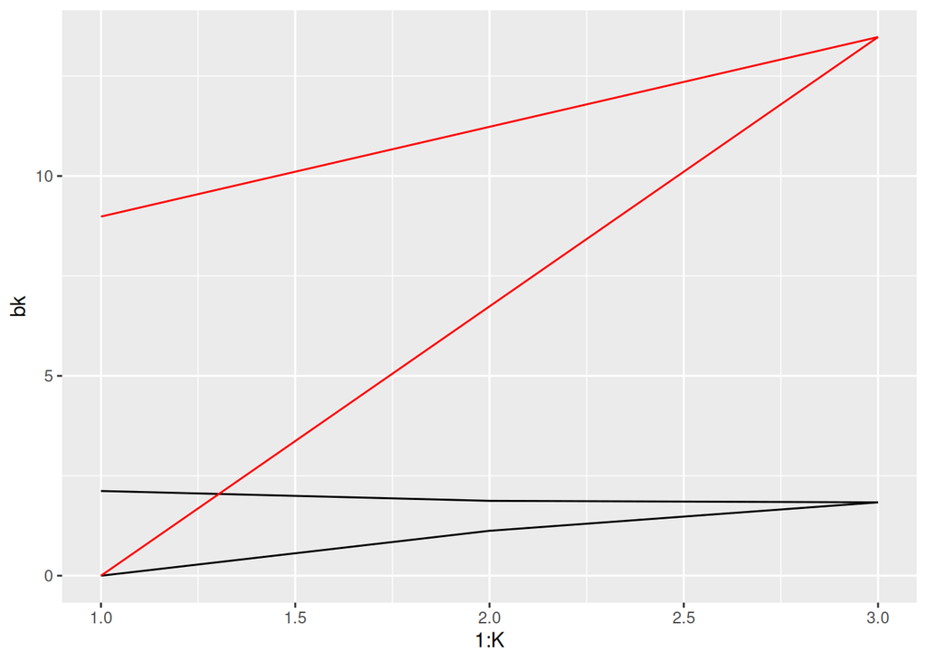

```r
# type I error
alpha <- 0.05

# number of analyses
K <- 3

# delta, true assumed clinically relevant difference
delta <- 0.5

Imax = (sqrt(4*0.583^2/K + 8*log(1/(2*alpha))) - 2*0.583/sqrt(K))^2/delta^2


# Score statistic

dk = (2/delta)*log(1/(2*alpha)) - 0.583*sqrt(Imax/K) + (delta/4)*((1:K)/K)*Imax
ck = -(2/delta)*log(1/(2*alpha)) + 0.583*sqrt(Imax/K) + (3*delta/4)*((1:K)/K)*Imax


ak = dk/sqrt(Imax*(1:K)/K)
bk = ck/sqrt(Imax*(1:K)/K)

ggplot() +
  geom_line(mapping = aes(x = 1:K, y = bk)) +
  geom_line(mapping = aes(x = 1:K, y = ak)) +
  geom_line(mapping = aes(x = 1:K, y = ck), color="red") +
  geom_line(mapping = aes(x = 1:K, y = dk), color="red")
```

## Other boundaries

According to the paper, the symmetric boundaries are calculated using the following formula:

$$r_l = C_{WT}\left(\frac{l}{L}\right)^{\Omega−0.5}$$

Pocock (1977) and O’Brien and Fleming (1979) boundaries take $\Omega = 0.5$ or $\Omega = 0$, respectively. Further, a numerical search is used for any chosen $\Omega$ to determine the value of $C_{WT}$ that implies the correct type I error rate $\alpha$. A further search is then used to ascertain the required sample size for the power constraint.

### Pocock

Boundaries given by $\Omega = 0.5$:

$$r_l = C_{WT}\left(\frac{l}{L}\right)^{0.5−0.5} = C_{WT}$$

Using our `gsd_simulations` function, we can perform this numerical search.

To perform the search as coded below, we need two functions that rounds down to the nearest power of ten.

```r
# round down to the nearest floor tenth, e.g., 0.004 -> 0.001
round_down10 <- function(x) 10^floor(log10(x))

# check that this is a whole number
is.wholenumber <- function(x, tol = .Machine$double.eps^0.5)  abs(x - round(x)) < tol
```

Now, we can use the below function to calculate the Pocock boundaries.

```r
calculate_pocock <- function(n_analyses = 3,
                             alpha = 0.05,
                             beta = 0.1,
                             epsilon = 0.00001,
                             n_patients = c(20, 40, 60)) {

  if(!is.wholenumber(log(epsilon, 10))) {
    stop("Epsilon must be at log base 10 intervals (e.g., 0.1, 0.01, 0.001.")
  }

  # hyperparameter tuned to get close to alpha needed
  z_mod <- -epsilon * 100

  initial_boundaries <- rep_len(qnorm(alpha/n_analyses), length.out = n_analyses)

  pk_upper_bounds <- -initial_boundaries
  pk_lower_bounds <- initial_boundaries

  sim_vals <- gsd_simulations(n_analyses = n_analyses,
                              upper_bounds = pk_upper_bounds,
                              lower_bounds = pk_lower_bounds,
                              n_patients = n_patients)

  while( round_down10(abs(sim_vals$alpha - alpha)) != epsilon){

    if ( round_down10(abs(sim_vals$alpha - alpha)) > epsilon) {
      initial_boundaries <- initial_boundaries - z_mod

      pk_upper_bounds <- -initial_boundaries
      pk_lower_bounds <- initial_boundaries

    } else if ( round_down10(abs(sim_vals$alpha - alpha)) < epsilon) {
      initial_boundaries <- initial_boundaries + z_mod

      pk_upper_bounds <- -initial_boundaries
      pk_lower_bounds <- initial_boundaries

    }

    sim_vals <- gsd_simulations(n_analyses = n_analyses,
                              upper_bounds = pk_upper_bounds,
                              lower_bounds = pk_lower_bounds,
                              n_patients = n_patients)

  }

  return( list(upper_bounds = pk_upper_bounds,
               lower_bounds = pk_lower_bounds,
               simulation = sim_vals) )

}
```

```r
calculate_pocock()
```

```
## $upper_bounds
## [1] 1.993045 1.993045 1.993045
##
## $lower_bounds
## [1] -1.993045 -1.993045 -1.993045
##
## $simulation
## $simulation$analysis_1
## futility_null efficacy_null  futility_alt  efficacy_alt
##  0.0231282470  0.0231282470  0.0001756609  0.3402040133
##
## $simulation$analysis_2
## futility_null efficacy_null  futility_alt  efficacy_alt
##  1.546020e-02  1.546020e-02  8.511684e-06  2.904928e-01
##
## $simulation$analysis_3
## futility_null efficacy_null  futility_alt  efficacy_alt
##  1.131565e-02  1.131502e-02  6.392175e-07  1.780095e-01
##
## $simulation$expected_sample_size
## [1] 29.10825
##
## $simulation$alpha
## [1] 0.04990346
##
## $simulation$power
## [1] 0.8087063
```

We can compare these boundaries with a published R package: `rpact`.

```r
library(rpact)
getDesignGroupSequential(
    sided = 1,
    alpha = 0.05,
    informationRates = c(0.33, 0.67, 1),
    typeOfDesign = "P"
)
```

*Design parameters and output of group sequential design*

*User defined parameters*

- *Type of design*: Pocock
- *Information rates*: 0.330, 0.670, 1.000
- *Significance level*: 0.0500

*Derived from user defined parameters*

- *Maximum number of stages*: 3

*Default parameters*

- *Stages*: 1, 2, 3
- *Type II error rate*: 0.2000
- *Futility bounds (non-binding)*: -Inf, -Inf
- *Binding futility*: FALSE
- *Test*: one-sided
- *Tolerance*: 1e-08

*Output*

- *Cumulative alpha spending*: 0.02315, 0.03873, 0.05000
- *Critical values*: 1.993, 1.993, 1.993
- *Stage levels (one-sided)*: 0.02315, 0.02315, 0.02315

### O’Brien-Fleming

Boundaries given by $\Omega = 0$:

$$r_l = C_{WT}\left(\frac{l}{L}\right)^{0−0.5} =
C_{WT}\left(\frac{l}{L}\right)^{−0.5}$$

```r
calculate_of <- function(n_analyses = 3,
                         alpha = 0.05,
                         beta = 0.1,
                         epsilon = 0.00001,
                         n_patients = c(20, 40, 60)) {

  if(!is.wholenumber(log(epsilon, 10))) {
    stop("Epsilon must be at log base 10 intervals (e.g., 0.1, 0.01, 0.001.")
  }

  # hyperparameter tuned to get close to alpha needed
  z_mod <- -epsilon * 100

  bounds_start <- rep_len(qnorm(alpha/n_analyses), length.out = n_analyses)

  initial_boundaries <- bounds_start * (1:n_analyses / n_analyses)^-0.5

  of_upper_bounds <- -initial_boundaries
  of_lower_bounds <- initial_boundaries

  sim_vals <- gsd_simulations(n_analyses = n_analyses,
                              upper_bounds = of_upper_bounds,
                              lower_bounds = of_lower_bounds,
                              n_patients = n_patients)

  while( round_down10(abs(sim_vals$alpha - alpha)) != epsilon){

    if ( round_down10(abs(sim_vals$alpha - alpha)) > epsilon) {

      bounds_start <- bounds_start - z_mod

      initial_boundaries <- bounds_start * (1:n_analyses / n_analyses)^-0.5

      of_upper_bounds <- -initial_boundaries
      of_lower_bounds <- initial_boundaries

    } else if ( round_down10(abs(sim_vals$alpha - alpha)) < epsilon) {

      bounds_start <- bounds_start + z_mod

      initial_boundaries <- bounds_start * (1:n_analyses / n_analyses)^-0.5

      of_upper_bounds <- -initial_boundaries
      of_lower_bounds <- initial_boundaries

    }

    sim_vals <- gsd_simulations(n_analyses = n_analyses,
                              upper_bounds = of_upper_bounds,
                              lower_bounds = of_lower_bounds,
                              n_patients = n_patients)

  }

  return( list(upper_bounds = of_upper_bounds,
               lower_bounds = of_lower_bounds,
               simulation = sim_vals) )

}
```

```r
calculate_of()
```

```
## $upper_bounds
## [1] 2.961885 2.094369 1.710045
##
## $lower_bounds
## [1] -2.961885 -2.094369 -1.710045
##
## $simulation
## $simulation$analysis_1
## futility_null efficacy_null  futility_alt  efficacy_alt
##  1.528809e-03  1.528809e-03  2.772646e-06  8.367847e-02
##
## $simulation$analysis_2
## futility_null efficacy_null  futility_alt  efficacy_alt
##  1.718510e-02  1.718510e-02  7.196005e-06  4.749465e-01
##
## $simulation$analysis_3
## futility_null efficacy_null  futility_alt  efficacy_alt
##  3.124598e-02  3.123870e-02  3.490707e-06  2.964627e-01
##
## $simulation$expected_sample_size
## [1] 38.45974
##
## $simulation$alpha
## [1] 0.0499526
##
## $simulation$power
## [1] 0.8550876
```

We can compare these boundaries with a published R package: `rpact`.

```r
getDesignGroupSequential(
    sided = 1,
    alpha = 0.05,
    informationRates = c(0.33, 0.67, 1),
    typeOfDesign = "OF"
)
```

*Design parameters and output of group sequential design*

*User defined parameters*

- *Information rates*: 0.330, 0.670, 1.000
- *Significance level*: 0.0500

*Derived from user defined parameters*

- *Maximum number of stages*: 3

*Default parameters*

- *Type of design*: O’Brien & Fleming
- *Stages*: 1, 2, 3
- *Type II error rate*: 0.2000
- *Futility bounds (non-binding)*: -Inf, -Inf
- *Binding futility*: FALSE
- *Test*: one-sided
- *Tolerance*: 1e-08

*Output*

- *Cumulative alpha spending*: 0.001457, 0.018928, 0.050000
- *Critical values*: 2.977, 2.089, 1.710
- *Stage levels (one-sided)*: 0.001457, 0.018353, 0.043640

## Compare sample sizes

Prepare a fuction that will calculate the expected sample size.

```r
simulate_ess <- function(upper_bounds = upper_bounds,
                         lower_bounds = lower_bounds) {

  delta_vector <- seq(from = 0, to = 1, length.out = 101)

  ess_vector <- vector(mode = "numeric", length = length(delta_vector))


  for (i in 1:length(delta_vector)) {
    ess_vector[i] <- gsd_simulations(upper_bounds = upper_bounds,
                                     lower_bounds = lower_bounds,
                                     alt_hypothesis = delta_vector[i])$expected_sample_size
  }

  return(ess_vector)
}
```

Calculate the boundaries.

```r
pocock_bounds <- calculate_pocock()
of_bounds <- calculate_of()
tri_bounds <- triangular_bounds()
```

Graph the bounds.

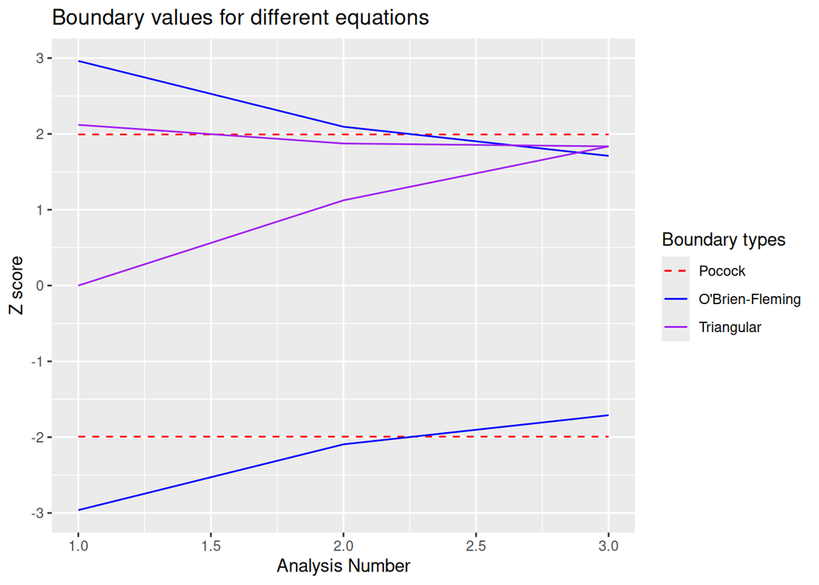

```r
ggplot() +
  geom_line(mapping = aes(x = 1:3, y = pocock_bounds$upper_bounds, color = "Pocock"),
            linetype = 2) +
  geom_line(mapping = aes(x = 1:3, y = pocock_bounds$lower_bounds, color = "Pocock"),
            linetype = 2) +
  geom_line(mapping = aes(x = 1:3, y = of_bounds$upper_bounds, color = "O'Brien-Fleming")) +
  geom_line(mapping = aes(x = 1:3, y = of_bounds$lower_bounds, color = "O'Brien-Fleming")) +
  geom_line(mapping = aes(x = 1:3, y = tri_bounds$upper_bounds, color = "Triangular")) +
  geom_line(mapping = aes(x = 1:3, y = tri_bounds$lower_bounds, color = "Triangular")) +
  scale_color_manual(name = "Boundary types",
                   breaks = c("Pocock", "O'Brien-Fleming", "Triangular"),
                   values = c("Pocock" = "red",
                              "O'Brien-Fleming" = "blue",
                              "Triangular" = "purple")) +
  labs(x = "Analysis Number", y = "Z score",
       title = "Boundary values for different equations")
```

Calculate the expected sample size vectors.

```r
pocock_ess <- simulate_ess(upper_bounds = pocock_bounds$upper_bounds,
                           lower_bounds = pocock_bounds$lower_bounds)

of_ess <- simulate_ess(upper_bounds = of_bounds$upper_bounds,
                       lower_bounds = of_bounds$lower_bounds)

tri_ess <- simulate_ess(upper_bounds = tri_bounds$upper_bounds,
                        lower_bounds = tri_bounds$lower_bounds)
```

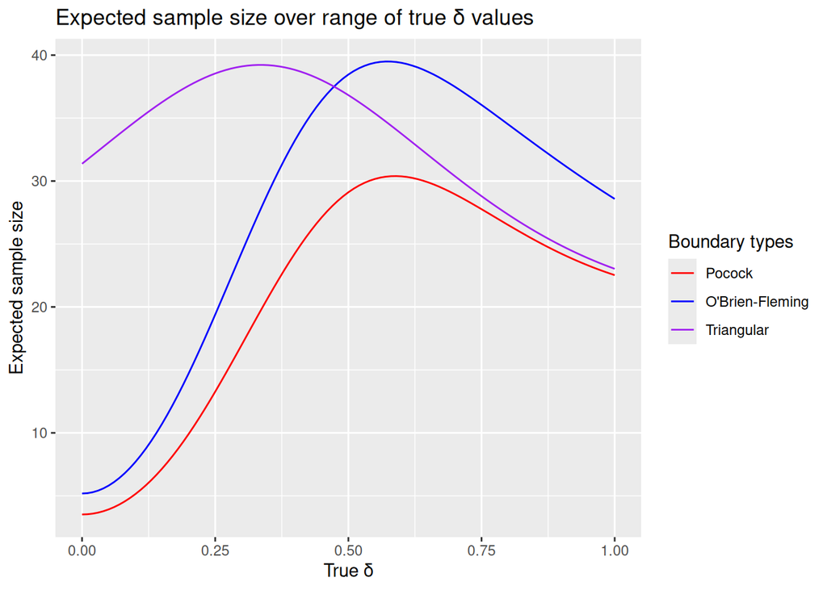

```r
delta_vector <- seq(from = 0, to = 1, length.out = 101)

ggplot() +
  geom_line(mapping = aes(x = delta_vector, y = pocock_ess, color = "Pocock")) +
  geom_line(mapping = aes(x = delta_vector, y = of_ess, color = "O'Brien-Fleming")) +
  geom_line(mapping = aes(x = delta_vector, y = tri_ess, color = "Triangular")) +
  scale_color_manual(name = "Boundary types",
                     breaks = c("Pocock", "O'Brien-Fleming", "Triangular"),
                     values = c("Pocock" = "red",
                                "O'Brien-Fleming" = "blue",
                                "Triangular" = "purple")) +
  labs(x = "True \u03B4", y = "Expected sample size",
       title = "Expected sample size over range of true \u03B4 values")
```

The maximum expected sample size is:

```r
max(pocock_ess)
```

```
## [1] 30.39239
```

```r
max(of_ess)
```

```
## [1] 39.49365
```

```r
max(tri_ess)
```

```
## [1] 39.22077
```

Expected sample size under the null:

```r
pocock_ess[delta_vector==0]
```

```
## [1] 3.520207
```

```r
of_ess[delta_vector==0]
```

```
## [1] 5.184612
```

```r
tri_ess[delta_vector==0]
```

```
## [1] 31.37291
```

Assuming the alternative is $\delta = 0.5$, we can calculate the sample size under the alternative as well:

```r
pocock_ess[delta_vector==0.5]
```

```
## [1] 29.10829
```

```r
of_ess[delta_vector==0.5]
```

```
## [1] 38.45936
```

```r
tri_ess[delta_vector==0.5]
```

```
## [1] 36.82225
```

# GP regression

```r
# load required libraries
library(gplite)
```

```r
library(plotly)
```

## Change restarts in `gp_optim`

Generate data for the function to which the model will be fit.

```r
n <- 5
x  <- matrix(seq(-2, 2, length.out = n), ncol = 1)
y  <- x^2
```

Plot the data.

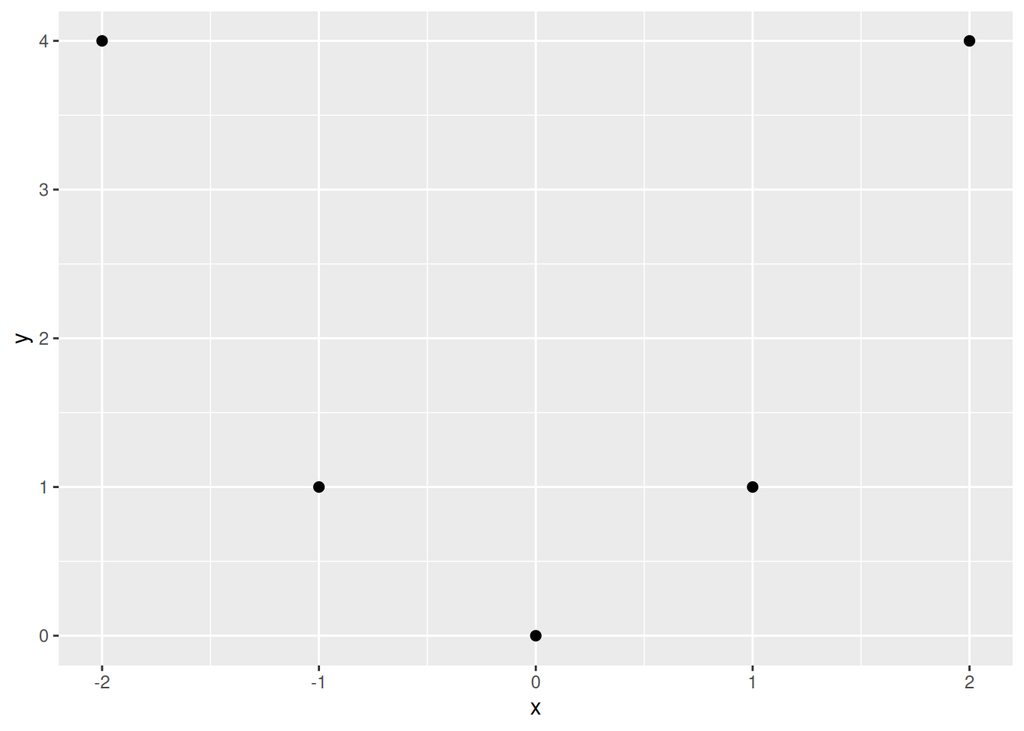

```r
ggplot() +
  geom_point(aes(x=x, y=y), size=2) +
  xlab('x') + ylab('y')
```

Initialize the GP model.

```r
# Specify the GP model we want to use:
gp_empty <- gp_init(

  # A squared exponential (aka Gaussian aka RBF) kernel
  cfs = cf_sexp(
    vars = NULL,
    lscale = 0.3,
    magn = 1,
    prior_lscale = prior_logunif(),
    prior_magn = prior_logunif(),
    normalize = FALSE
  ),

  # Assume Gaussian distributed errors
  lik = lik_gaussian(
    sigma = 0.5,
    prior_sigma = prior_logunif()
  ),

  # Use the full covariance (i.e., do not approximate)
  method = method_full()

)
```

Optimize the model using the internal function.

```r
# Now fit the model to the data:
gp_optimized <- gp_optim(gp_empty, x, y, verbose = FALSE)
```

Plot the model.

```r
# compute the predictive mean and variance in a grid of points
xt   <- seq(-4, 4, len=150)
pred <- gp_pred(gp_optimized, xt, var = T)

# visualize
mu <- pred$mean
lb <- pred$mean - 2*sqrt(pred$var)
ub <- pred$mean + 2*sqrt(pred$var)

ggplot() +
  geom_ribbon(aes(x=xt, ymin=lb, ymax=ub), fill='lightgray') +
  geom_line(aes(x=xt, y=mu), linewidth = 0.5) +
  geom_point(aes(x=x, y=y), size=2) +
  xlab('x') + ylab('y')
```

[output not shown]

Pull the energy.

```r
gp_energy(gp_optimized)
```

```
## [1] 11.887
```

Increase the number of restarts.

```r
# Now fit the model to the data:
gp_optimized_10 <- gp_optim(

  gp = gp_empty,
  x = x,
  y = y,
  restarts = 10,
  verbose = FALSE

)
```

Plot the model with larger number of restarts.

```r
# compute the predictive mean and variance in a grid of points
pred <- gp_pred(gp_optimized_10, xt, var = T)

# visualize
mu <- pred$mean
lb <- pred$mean - 2*sqrt(pred$var)
ub <- pred$mean + 2*sqrt(pred$var)

ggplot() +
  geom_ribbon(aes(x=xt, ymin=lb, ymax=ub), fill='lightgray') +
  geom_line(aes(x=xt, y=mu), linewidth = 0.5) +
  geom_point(aes(x=x, y=y), size=2) +
  xlab('x') + ylab('y')
```

[output not shown]

Pull the energy.

```r
gp_energy(gp_optimized_10)
```

```
## [1] 11.887
```

Increase to 1000 restarts.

```r
# Now fit the model to the data:
gp_optimized_1000 <- gp_optim(

  gp = gp_empty,
  x = x,
  y = y,
  restarts = 1000,
  verbose = FALSE

)
```

Plot the model with larger number of restarts.

```r
# compute the predictive mean and variance in a grid of points
pred <- gp_pred(gp_optimized_1000, xt, var = T)

# visualize
mu <- pred$mean
lb <- pred$mean - 2*sqrt(pred$var)
ub <- pred$mean + 2*sqrt(pred$var)

ggplot() +
  geom_ribbon(aes(x=xt, ymin=lb, ymax=ub), fill='lightgray') +
  geom_line(aes(x=xt, y=mu), linewidth = 0.5) +
  geom_point(aes(x=x, y=y), size=2) +
  xlab('x') + ylab('y')
```

[output not shown]

Pull the energy.

```r
gp_energy(gp_optimized_1000)
```

```
## [1] 11.887
```

Increase to 1,000,000 restarts.

```r
# Now fit the model to the data:
gp_optimized_1e6 <- gp_optim(

  gp = gp_empty,
  x = x,
  y = y,
  restarts = 1e6,
  verbose = FALSE

)
```

Plot the model with larger number of restarts.

```r
# compute the predictive mean and variance in a grid of points
pred <- gp_pred(gp_optimized_1e6, xt, var = T)

# visualize
mu <- pred$mean
lb <- pred$mean - 2*sqrt(pred$var)
ub <- pred$mean + 2*sqrt(pred$var)

ggplot() +
  geom_ribbon(aes(x=xt, ymin=lb, ymax=ub), fill='lightgray') +
  geom_line(aes(x=xt, y=mu), linewidth = 0.5) +
  geom_point(aes(x=x, y=y), size=2) +
  xlab('x') + ylab('y')
```

[output not shown]

Pull the energy.

```r
gp_energy(gp_optimized_1e6)
```

```
## [1] 11.887
```

## Marginal likelihood surface; more points

### Original surface plot.

```r
ell <- seq(0.5, 3, by = 0.05)

sigma_f <- seq(2, 8, by = 0.05)

hyperparams <- expand.grid(
  ell = ell,
  sigma_f = sigma_f
)

# collect energies in the empty vector
energy <- c()

# run 6000+ models
for (i in 1:dim(hyperparams)[1]) {

  gp_empty <- gp_init(
    # A squared exponential (aka Gaussian aka RBF) kernel
    cfs = cf_sexp(
      vars = NULL,
      lscale = hyperparams$ell[i],
      magn = hyperparams$sigma_f[i],
      prior_lscale = prior_logunif(),
      prior_magn = prior_logunif(),
      normalize = FALSE
    ),

    # Assume Gaussian distributed errors
    lik = lik_gaussian(
      sigma = 0.01,
      prior_sigma = prior_logunif()
    ),

    # Use the full covariance (i.e., do not approximate)
    method = method_full()
  )

  gp_raw <- gp_fit(gp_empty, x, y)

  energy[i] <- gp_energy(gp_raw)

}

surface_plot <- cbind(hyperparams, energy)

surface_plot[which.min(surface_plot$energy),]
```

```
##       ell sigma_f   energy
## 4212 1.95     6.1 11.05812
```

Model with $\ell = 2$ and $\sigma_f^2 = 6$, near the optimal values. Recall that we are setting $\sigma_n^2 = 0.01$.

```r
# Specify the GP model we want to use,
# we will specify the lscale and magn using values from above
gp_empty <- gp_init(
  # A squared exponential (aka Gaussian aka RBF) kernel
  cfs = cf_sexp(
    vars = NULL,
    lscale = 2,
    magn = 6,
    prior_lscale = prior_logunif(),
    prior_magn = prior_logunif(),
    normalize = FALSE
  ),

  # Assume Gaussian distributed errors
  lik = lik_gaussian(
    sigma = 0.01,
    prior_sigma = prior_logunif()
  ),

  # Use the full covariance (i.e., do not approximate)
  method = method_full()
)

gp_raw_ell2sigma6 <- gp_fit(gp_empty, x, y)
```

Plot the model.

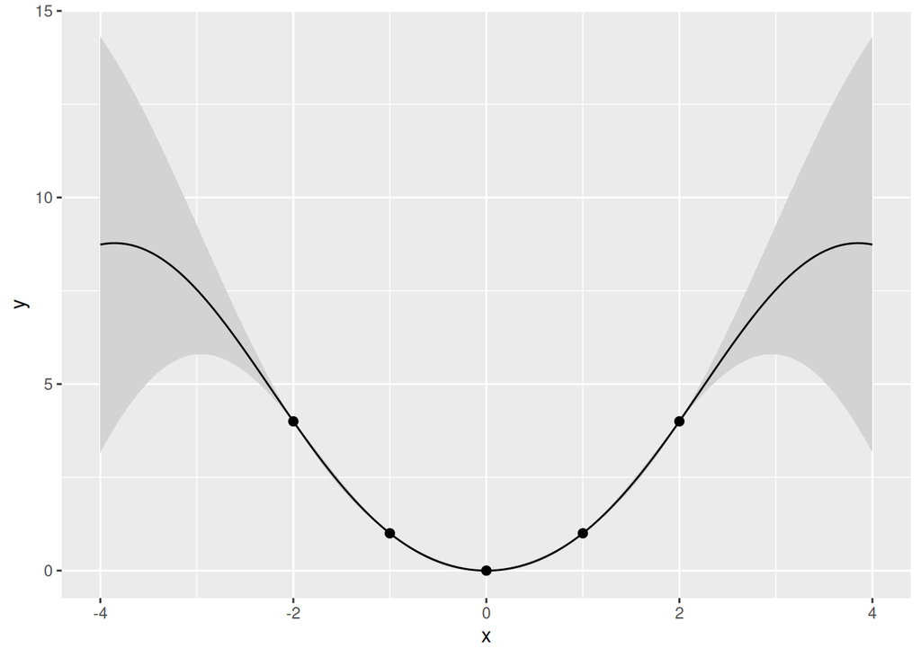

```r
# compute the predictive mean and variance in a grid of points
pred_ell2sigma6 <- gp_pred(gp_raw_ell2sigma6, xt, var = T)

# visualize
mu_ell2sigma6 <- pred_ell2sigma6$mean
lb_ell2sigma6 <- pred_ell2sigma6$mean - 2*sqrt(pred_ell2sigma6$var)
ub_ell2sigma6 <- pred_ell2sigma6$mean + 2*sqrt(pred_ell2sigma6$var)

ggplot() +
  geom_ribbon(aes(x=xt, ymin=lb_ell2sigma6, ymax=ub_ell2sigma6), fill='lightgray') +
  geom_line(aes(x=xt, y=mu_ell2sigma6), linewidth = 0.5) +
  geom_point(aes(x=x, y=y), size=2) +
  xlab('x') + ylab('y')
```

Plot the entire surface.

```r
fig <- plot_ly() %>%

  add_trace(
    x = unique(surface_plot$sigma_f),
    y = unique(surface_plot$ell),
    z = matrix(surface_plot$energy, nrow = 51, ncol = 121),
    type = "surface") %>%

  add_trace(
    x = 6.1,
    y = 1.95,
    z = 11.05812,
    type = "scatter3d",
    mode = "markers"
  ) %>%

  layout(
    scene = list(
      aspectmode = 'manual',  # Set to manual for custom aspect ratio
      aspectratio = list(x = 1, y = 1, z = 0.5),  # Adjust x, y, z ratios

      xaxis = list(
        title = "signal variance"
      ),

      yaxis = list(
        title = "length-scale parameter"
      ),

      zaxis = list(
        title = "-log(marginal likelihood)"
      )
    )
  )

fig
```

[interactive chart not shown]

Plot the surface nearest the optimum value.

```r
fig <- plot_ly() %>%

  add_trace(
    x = unique(surface_plot$sigma_f)[80:121],
    y = unique(surface_plot$ell)[10:51],
    z = matrix(surface_plot$energy, nrow = 51, ncol = 121)[10:51, 80:121],
    type = "surface") %>%

  add_trace(
    x = 6.1,
    y = 1.95,
    z = 11.05812,
    type = "scatter3d",
    mode = "markers"
  ) %>%

  layout(
    scene = list(
      aspectmode = 'manual',  # Set to manual for custom aspect ratio
      aspectratio = list(x = 1, y = 1, z = 0.5),  # Adjust x, y, z ratios

      xaxis = list(
        title = "signal variance"
      ),

      yaxis = list(
        title = "length-scale parameter"
      ),

      zaxis = list(
        title = "-log(marginal likelihood)"
      )
    )
  )

fig
```

[interactive chart not shown]

### More points!

```r
# n is 7 now; used to be 5
n_new <- 7
x_new  <- matrix(seq(-2, 2, length.out = n_new), ncol = 1)
y_new  <- x_new^2
```

Plot the data.

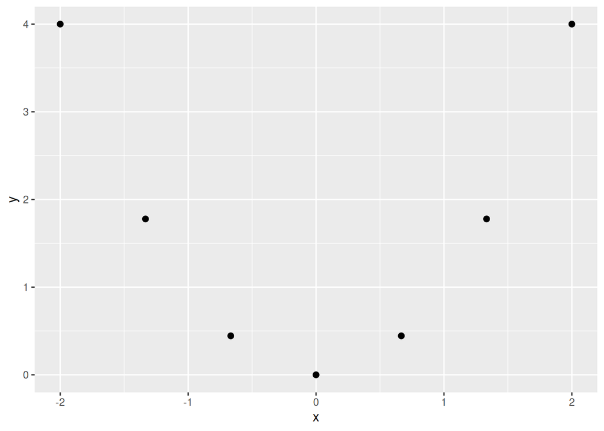

```r
ggplot() +
  geom_point(aes(x = x_new, y = y_new), size=2) +
  xlab('x') + ylab('y')
```

Now, fit the model using `gp_optim`.

```r
gp_empty_7 <- gp_init(

  # A squared exponential (aka Gaussian aka RBF) kernel
  cfs = cf_sexp(
    vars = NULL,
    lscale = 0.3,
    magn = 1,
    prior_lscale = prior_logunif(),
    prior_magn = prior_logunif(),
    normalize = FALSE
  ),

  # Assume Gaussian distributed errors
  lik = lik_gaussian(
    sigma = 0.5,
    prior_sigma = prior_logunif()
  ),

  # Use the full covariance (i.e., do not approximate)
  method = method_full()

)
```

Optimize.

```r
gp_optimized_7 <- gp_optim(gp = gp_empty_7,
                           x = x_new,
                           y = y_new,
                           restarts = 5,
                           verbose = TRUE)
```

```
## Optimizing parameters
## p1: log cf_sexp.lscale
## p2: log cf_sexp.magn
## p3: log lik_gaussian.sigma
##
##       p1       p2       p3     Energy Iteration
##    -1.20     0.00    -0.69      21.92         0
##    -1.08     0.00    -0.69      21.45         1
##    -1.20     0.12    -0.69      19.95         2
##    -1.20     0.00    -0.57      21.38         3
##    -1.12     0.08    -0.61      20.04         4
##    -1.14     0.06    -0.63      20.47         5
##    -1.27     0.13    -0.56      19.57         6
##    -1.36     0.20    -0.49      18.77         7
##    -1.26     0.27    -0.63      18.15         8
##    -1.28     0.40    -0.65      17.09         9
##    -1.44     0.40    -0.61      17.24        10
##    -1.36     0.32    -0.61      17.81        11
##    -1.53     0.55    -0.48      16.39        12
##    -1.69     0.76    -0.37      15.93        13
##    -1.58     0.84    -0.60      15.91        14
##    -1.69     1.16    -0.65      16.51        15
##    -1.59     0.94    -0.47      15.99        16
##    -1.55     0.80    -0.51      15.90        17
##    -1.93     1.20    -0.33      16.68        18
##    -1.77     1.00    -0.41      16.11        19
##    -1.44     0.60    -0.57      16.20        20
##    -1.69     0.90    -0.45      15.96        21
##    -1.53     0.70    -0.53      15.98        22
##    -1.65     0.85    -0.47      15.92        23
##    -1.50     0.90    -0.68      15.92        24
##    -1.55     0.87    -0.60      15.91        25
##    -1.47     0.82    -0.67      15.88        26
##    -1.38     0.81    -0.76      15.84        27
##    -1.46     0.77    -0.64      15.90        28
##    -1.48     0.79    -0.63      15.89        29
##    -1.37     0.76    -0.67      15.85        30
##    -1.42     0.78    -0.65      15.87        31
##    -1.27     0.77    -0.87      15.77        32
##    -1.13     0.75    -1.05      15.61        33
```

[output cut: 95 more lines]

```
##     3.84     7.32   -10.89      -1.65       129
##     3.86     7.28   -10.96      -1.61       130
##     3.79     7.27   -10.79      -1.65       131
##     3.81     7.30   -10.80      -1.65       132
##     3.81     7.26   -10.84      -1.66       133
##     3.77     7.19   -10.73      -1.65       134
##     3.82     7.29   -10.85      -1.66       135
## Assessing convergence...
##     3.90     7.24   -10.80      -1.42       136
##     3.70     7.24   -10.80      -1.50       137
##     3.80     7.34   -10.80      -1.63       138
##     3.80     7.14   -10.80      -1.60       139
##     3.80     7.24   -10.70      -1.66       140
##     3.80     7.24   -10.90      -1.66       141
## Optimization converged.
```

Optimal value of $\sigma_f^2 = 7.24$ and optimal value of $\ell=3.8$.

Pull the energy.

```r
gp_energy(gp_optimized_7)
```

```
## [1] -1.65625
```

Plot the optimal model.

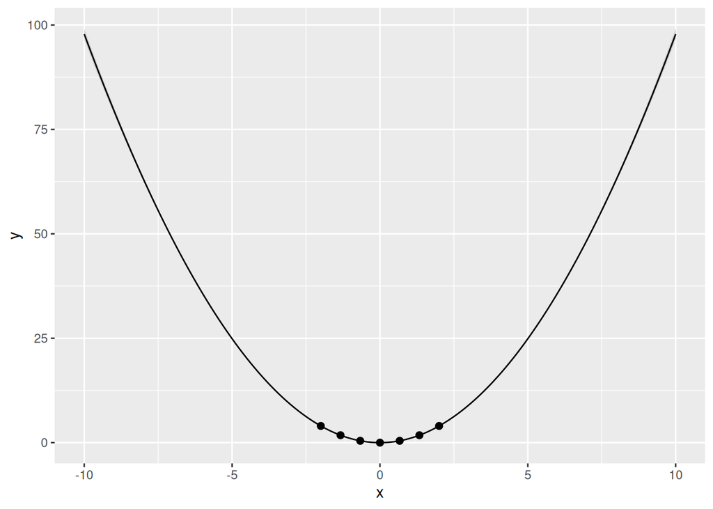

```r
xt_more <- seq(-10, 10, len=150)
pred_7 <- gp_pred(gp = gp_optimized_7,
                  xnew = xt_more,
                  var = TRUE)

mu_pred_7 <- pred_7$mean
lb_pred_7 <- pred_7$mean - 2*sqrt(pred_7$var)
ub_pred_7 <- pred_7$mean + 2*sqrt(pred_7$var)

ggplot() +
  geom_ribbon(aes(x=xt_more, ymin=lb_pred_7, ymax=ub_pred_7), fill='lightgray') +
  geom_line(aes(x=xt_more, y=mu_pred_7), linewidth = 0.5) +
  geom_point(aes(x=x_new, y=y_new), size=2) +
  xlab('x') + ylab('y')
```

### Generate the surface

Recall, optimal value of $\sigma_f^2 = 7.24$ and optimal value of $\ell=3.8$. We will set $\sigma_n^2 = 0.01$.

```r
# using prior optimization, set sequence
ell <- seq(1, 6, by = 0.05)

# using prior optimization, set sequence
sigma_f <- seq(4, 10, by = 0.05)

hyperparams <- expand.grid(
  ell = ell,
  sigma_f = sigma_f
)

# collect energies in the empty vector
energy <- vector(mode = "numeric", length = dim(hyperparams)[1])

# run 6000+ models
for (i in 1:dim(hyperparams)[1]) {

  gp_empty <- gp_init(
    # A squared exponential (aka Gaussian aka RBF) kernel
    cfs = cf_sexp(
      vars = NULL,
      lscale = hyperparams$ell[i],
      magn = hyperparams$sigma_f[i],
      prior_lscale = prior_logunif(),
      prior_magn = prior_logunif(),
      normalize = FALSE
    ),

    # Assume Gaussian distributed errors
    lik = lik_gaussian(
      sigma = 0.01,
      prior_sigma = prior_logunif()
    ),

    # Use the full covariance (i.e., do not approximate)
    method = method_full()
  )

  gp_raw <- gp_fit(gp_empty, x_new, y_new)

  energy[i] <- gp_energy(gp_raw)

}

surface_plot <- cbind(hyperparams, energy)

surface_plot[which.min(surface_plot$energy),]
```

```
##       ell sigma_f   energy
## 12159 2.9      10 5.433649
```

Is the range of energies lower value?

```r
range(surface_plot$energy)
```

```
## [1]  5.433649 97.868111
```

Plot the surface.

```r
fig <- plot_ly() %>%

  add_trace(
    x = unique(surface_plot$sigma_f),
    y = unique(surface_plot$ell),
    z = matrix(surface_plot$energy, nrow = 101, ncol = 121),
    type = "surface") %>%

  add_trace(
    x = 10,
    y = 2.9,
    z = 5.433,
    type = "scatter3d",
    mode = "markers"
  ) %>%

  layout(
    scene = list(
      aspectmode = 'manual',  # Set to manual for custom aspect ratio
      aspectratio = list(x = 1, y = 1, z = 0.5),  # Adjust x, y, z ratios

      xaxis = list(
        title = "signal variance"
      ),

      yaxis = list(
        title = "length-scale parameter"
      ),

      zaxis = list(
        title = "-log(marginal likelihood)"
      )
    )
  )

fig
```

[interactive chart not shown]

Plot the surface with lowest energies.

```r
fig <- plot_ly() %>%

  add_trace(
    x = unique(surface_plot$sigma_f),
    y = unique(surface_plot$ell)[1:45],
    z = matrix(surface_plot$energy, nrow = 101, ncol = 121)[1:45, ],
    type = "surface") %>%

  add_trace(
    x = 10,
    y = 2.9,
    z = 5.433,
    type = "scatter3d",
    mode = "markers"
  ) %>%

  layout(
    scene = list(
      aspectmode = 'manual',  # Set to manual for custom aspect ratio
      aspectratio = list(x = 1, y = 1, z = 0.5),  # Adjust x, y, z ratios

      xaxis = list(
        title = "signal variance"
      ),

      yaxis = list(
        title = "length-scale parameter"
      ),

      zaxis = list(
        title = "-log(marginal likelihood)"
      )
    )
  )

fig
```

[interactive chart not shown]

## Broken optimization

$n=7$ works, but $n=8$ or $n=9$ does not.

```r
# n is 8 now
n_new <- 8
x_new  <- matrix(seq(-2, 2, length.out = n_new), ncol = 1)
y_new  <- x_new^2
```

Plot the data.

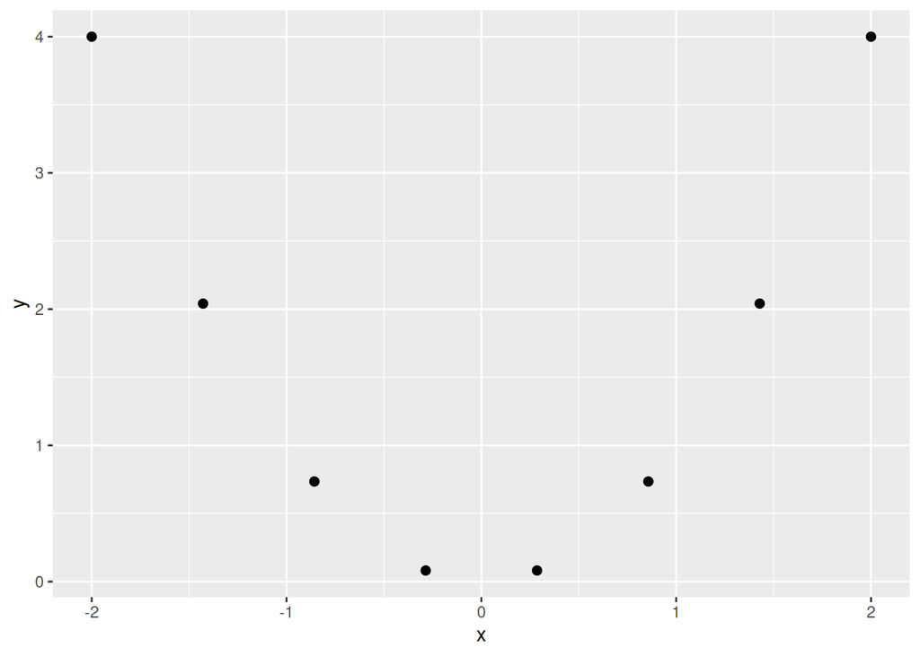

```r
ggplot() +
  geom_point(aes(x = x_new, y = y_new), size=2) +
  xlab('x') + ylab('y')
```

Now, fit the model using `gp_optim`.

```r
gp_empty_8 <- gp_init(

  # A squared exponential (aka Gaussian aka RBF) kernel
  cfs = cf_sexp(
    vars = NULL,
    lscale = 0.3,
    magn = 1,
    prior_lscale = prior_logunif(),
    prior_magn = prior_logunif(),
    normalize = FALSE
  ),

  # Assume Gaussian distributed errors
  lik = lik_gaussian(
    sigma = 0.5,
    prior_sigma = prior_logunif()
  ),

  # Use the full covariance (i.e., do not approximate)
  method = method_full()

)
```

Optimize.

```r
gp_optimized_8 <- gp_optim(gp = gp_empty_8,
                           x = x_new,
                           y = y_new,
                           restarts = 5,
                           verbose = FALSE)
```

```
## Error in chol.default(B): the leading minor of order 4 is not positive
```

# Exploring `mvtnorm`

```r
library(bench)
```

`pmvnorm` is “smart” when it comes to single dimensional computations as it passes the values to `pnorm`.

```r
cat("pmvnorm\n\n")
```

```
## pmvnorm
```

```r
pmvnorm(lower = -Inf, upper = 2, mean = 0, sigma = 1)
```

```
##     upper
## 0.9772499
## attr(,"error")
## [1] 0
## attr(,"msg")
## [1] "univariate: using pnorm"
```

```r
cat("\n\n")
```

```r
cat("pnorm\n\n")
```

```
## pnorm
```

```r
pnorm(2)
```

```
## [1] 0.9772499
```

```r
pmvnorm(lower = c(-Inf, -Inf), upper = c(Inf, 2), mean = c(0,0), sigma = diag(2))
```

```
## [1] 0.9772499
## attr(,"error")
## [1] 2e-16
## attr(,"msg")
## [1] "Normal Completion"
```

```r
bench::mark(
  # 2d
  pmvnorm(lower = c(-Inf, -Inf), upper = c(0, Inf),
          mean = c(0,0), corr = diag(2)),
  # 3d
  pmvnorm(lower = c(-Inf, -Inf, -Inf), upper = c(0, Inf, Inf),
          mean = c(0,0,0), corr = diag(3)),
  check = FALSE
)
```

```
## # A tibble: 2 × 6
##   expression                             min median `itr/sec` mem_alloc `gc/sec`
##   <bch:expr>                          <bch:> <bch:>     <dbl> <bch:byt>    <dbl>
## 1 pmvnorm(lower = c(-Inf, -Inf), upp… 55.5µs 66.8µs    11598.    2.49KB    10.5
## 2 pmvnorm(lower = c(-Inf, -Inf, -Inf… 53.8µs 63.7µs    12449.    2.49KB     8.32
```

```r
bench::mark(
  # 2d
  pmvnorm(lower = c(-Inf, -Inf), upper = c(0, Inf),
          mean = c(0,0), corr = diag(2)),
  # 3d
  pmvnorm(lower = c(-Inf, -Inf, -Inf), upper = c(0, Inf, Inf),
          mean = c(0,0,0), corr = diag(3),
          algorithm = Miwa()),
  check = FALSE
)
```

```
## # A tibble: 2 × 6
##   expression                             min median `itr/sec` mem_alloc `gc/sec`
##   <bch:expr>                          <bch:> <bch:>     <dbl> <bch:byt>    <dbl>
## 1 pmvnorm(lower = c(-Inf, -Inf), upp… 54.5µs 63.6µs    12423.    2.49KB    10.5
## 2 pmvnorm(lower = c(-Inf, -Inf, -Inf… 42.7µs 58.3µs    11449.    4.96KB     8.36
```

The Miwa algorithm does collapse multidimensional integrals.

```r
pmvnorm(lower = c(-3, -Inf, -Inf), upper = c(0, Inf, Inf),
        mean = c(0,0,0), corr = diag(3),
        algorithm = Miwa())
```

```
## [1] 0.4986501
## attr(,"error")
## [1] 0
## attr(,"msg")
## [1] "Normal Complettion (dim reduced to 1)"
```

```r
pmvnorm(lower = c(-Inf, -Inf, -4), upper = c(Inf, Inf, 0),
        mean = c(0,0,0), corr = diag(3),
        algorithm = Miwa())
```

```
## [1] 0.4999683
## attr(,"error")
## [1] 0
## attr(,"msg")
## [1] "Normal Complettion (dim reduced to 1)"
```

```r
pmvnorm(lower = c(-Inf, -2, -Inf), upper = c(Inf, 0, Inf),
        mean = c(0,0,0), corr = diag(3),
        algorithm = Miwa())
```

```
## [1] 0.4772499
## attr(,"error")
## [1] 0
## attr(,"msg")
## [1] "Normal Complettion (dim reduced to 1)"
```

We can assess larger dimensional integrals.

```r
bench::mark(

  pmvnorm(
    lower = c(-2, -0.3, 0, -0.6, 0.01, -1, -2, -3, -1, 0.2),
    upper = rep(1, length.out = 10),
    mean = rep(0, length.out = 10),
    sigma = diag(10),
    algorithm = GenzBretz()
  ),

  pmvnorm(
    lower = c(-2, -0.3, 0, -0.6, 0.01, -1, -2, -3, -1, 0.2),
    upper = rep(1, length.out = 10),
    mean = rep(0, length.out = 10),
    sigma = diag(10),
    algorithm = Miwa()
  ),

  pmvnorm(
    lower = c(-Inf, -Inf, -Inf),
    upper = c(0, Inf, Inf),
    mean = c(0, 0, 0),
    corr = diag(3),
    algorithm = GenzBretz()
  ),

  pmvnorm(
    lower = c(-Inf, -Inf, -Inf),
    upper = c(0, Inf, Inf),
    mean = c(0, 0, 0),
    corr = diag(3),
    algorithm = Miwa()
  ),

  pmvnorm(
    lower = c(-Inf, -Inf, -Inf, -Inf),
    upper = c(0, Inf, Inf, Inf),
    mean = c(0, 0, 0),
    corr = diag(4),
    algorithm = GenzBretz()
  ),

  pmvnorm(
    lower = c(-Inf, -Inf, -Inf, -Inf),
    upper = c(0, Inf, Inf, Inf),
    mean = c(0, 0, 0),
    corr = diag(4),
    algorithm = Miwa()
  ),

  pmvnorm(
    lower = c(-Inf, -0.3, 0, -0.6, 0.01, -Inf, -2, -3, -1, 0.2),
    upper = c(Inf, 1, 3, 2, 1, 0.4, Inf, 1, 2, 3),
    mean = rep(0, length.out = 10),
    sigma = diag(10),
    algorithm = GenzBretz()
  ),

  pmvnorm(
    lower = c(-Inf, -0.3, 0, -0.6, 0.01, -Inf, -2, -3, -1, 0.2),
    upper = c(Inf, 1, 3, 2, 1, 0.4, Inf, 1, 2, 3),
    mean = rep(0, length.out = 10),
    sigma = diag(10),
    algorithm = Miwa()
  ),

  check = FALSE
)
```

```
## # A tibble: 8 × 6
##   expression                           min   median `itr/sec` mem_alloc `gc/sec`
##   <bch:expr>                      <bch:tm> <bch:tm>     <dbl> <bch:byt>    <dbl>
## 1 pmvnorm(lower = c(-2, -0.3, 0,…  13.65ms  15.28ms      64.6   15.63KB     0
## 2 pmvnorm(lower = c(-2, -0.3, 0,…   52.9ms  56.48ms      17.8   37.33KB     0
## 3 pmvnorm(lower = c(-Inf, -Inf, …  54.37µs  64.53µs   11454.     2.49KB    10.7
## 4 pmvnorm(lower = c(-Inf, -Inf, …  45.73µs  54.43µs   14057.         0B     8.38
## 5 pmvnorm(lower = c(-Inf, -Inf, … 239.11µs 350.98µs    2408.    74.28KB     6.20
## 6 pmvnorm(lower = c(-Inf, -Inf, … 186.39µs 280.43µs    3060.    67.24KB     6.19
## 7 pmvnorm(lower = c(-Inf, -0.3, …   7.14ms   7.76ms     128.    15.63KB     2.03
## 8 pmvnorm(lower = c(-Inf, -0.3, …  22.02ms  25.12ms      39.7   82.41KB     0
```